# Acer Microbiome to Phyloseq

```r
set.seed(100)
#library("devtools")
library("ggmap")
library("plotrix")
library("sf")
library("rgdal")
library("tidyverse")
library("taxa")
library("phyloseq")
library("ggplot2")
library("vegan")
library("ggpubr")
library("sciplot")
library("multcompView")
library("patchwork")
library("pacman")
library("ggrepel")
library("paletteer")
library("plyr")
library("grid")
library("reshape2")
library("scales")
library("magrittr")
library("ape")
library("RColorBrewer")
library("tidyverse")
library("corncob")
library(forcats)
windowsFonts("Times New Roman" = windowsFont("Times New Roman"))
```

### Get the data and make full dataset phyloseq objects

```r
ps_acer<-readRDS("acer_ps_rename_rare.rds")
ps_acer
```

```
phyloseq-class experiment-level object
otu_table()   OTU Table:         [ 1195 taxa and 74 samples ]
sample_data() Sample Data:       [ 74 samples by 13 sample variables ]
tax_table()   Taxonomy Table:    [ 1195 taxa by 7 taxonomic ranks ]
```

```r
ps_acer_norare<-readRDS("acer_ps_rename.rds")
ps_acer_norare
```

```
phyloseq-class experiment-level object
otu_table()   OTU Table:         [ 1290 taxa and 74 samples ]
sample_data() Sample Data:       [ 74 samples by 13 sample variables ]
tax_table()   Taxonomy Table:    [ 1290 taxa by 7 taxonomic ranks ]
```

```r
tax_table(ps_acer)
```

[output not shown]

[output cut: 519 more lines]

```
ASV_129  "Genus_Novosphingobium"
ASV_130  "Family_Rhizobiaceae"
ASV_131  "Aquarickettsia"
ASV_132  "Genus_Bifidobacterium"
ASV_133  "Genus_Neisseria"
ASV_134  "valens"
ASV_135  "Genus_Methylobacterium"
ASV_136  "Genus_Urania-1B-19_marine_sediment_group"
ASV_137  "Unclassified_ASV_137"
ASV_138  "Genus_Vibrio"
ASV_139  "Genus_Weissella"
ASV_140  "Family_Clade_III"
ASV_141  "Family_AKYH767"
ASV_142  "Genus_Sphingomonas"
 [ reached getOption("max.print") -- omitted 1053 rows ]
```

```r
d<-data.frame()
d <- data.frame(sample_data(ps_acer))
d[d$Region=="Middle Keys",]$Outlier<-"No" #wasn't saved in phyloseq object used so have to add now
#add the time spent in nursery columns
di<-read.csv("acer_metadata_update_1_21_2021.csv")
di<-di[1:74,15:17]
d <- cbind(d, di)
sample_data(ps_acer)<-d
```

## Now subset the phyloseq object

```r
ps_lowno<-subset_samples(ps_acer,Outlier!="Yes"&Region=="Lower Keys")
ps_upno<-subset_samples(ps_acer,Outlier!="Yes"&Region=="Upper Keys")
ps_midno<-subset_samples(ps_acer,Outlier!="Yes"&Region=="Middle Keys")
ps_noout<-subset_samples(ps_acer,Outlier!="Yes")
ps_justout<-subset_samples(ps_acer,Outlier=="Yes")
ps_low<-subset_samples(ps_acer,Region=="Lower Keys")
ps_up<-subset_samples(ps_acer,Region=="Upper Keys")
ps_mid<-subset_samples(ps_acer,Region=="Middle Keys")
ps_noout<-merge_phyloseq(ps_lowno,ps_upno,ps_mid)
ps_lowout<-subset_samples(ps_acer,Outlier=="Yes"&Region=="Lower Keys")
ps_upout<-subset_samples(ps_acer,Outlier=="Yes"&Region=="Upper Keys")

#simplify names to go with later code
ps<-ps_acer #full dataset
psout<-ps_justout #just outliers
psnoout<-ps_noout #no outliers
```

### transform full dataset to bray curtis distance and run PERMANOVA

```r
perma<- function(p){ #needs a phyloseq object
  df = as(sample_data(p), "data.frame")
  d = phyloseq::distance(p, "bray")
  df$Site <- as.factor(df$Region)
  PERMANOVA <- adonis2(d ~ Site, df)
  PERMANOVA
}
print("full dataset")
```

```
[1] "full dataset"
```

```r
permfull<-perma(ps)
permfull
```

```
Permutation test for adonis under reduced model
Terms added sequentially (first to last)
Permutation: free
Number of permutations: 999

adonis2(formula = d ~ Site, data = df)
         Df SumOfSqs      R2     F Pr(>F)
Site      2   1.2658 0.15404 6.464  0.002 **
Residual 71   6.9519 0.84596
Total    73   8.2177 1.00000
---
Signif. codes:  0 ‘***’ 0.001 ‘**’ 0.01 ‘*’ 0.05 ‘.’ 0.1 ‘ ’ 1
```

```r
print("outlier dataset")
```

```
[1] "outlier dataset"
```

```r
permout<-perma(psout)
permout
```

```
Permutation test for adonis under reduced model
Terms added sequentially (first to last)
Permutation: free
Number of permutations: 999

adonis2(formula = d ~ Site, data = df)
         Df SumOfSqs      R2     F Pr(>F)
Site      1  0.87026 0.39283 5.176  0.012 *
Residual  8  1.34509 0.60717
Total     9  2.21535 1.00000
---
Signif. codes:  0 ‘***’ 0.001 ‘**’ 0.01 ‘*’ 0.05 ‘.’ 0.1 ‘ ’ 1
```

```r
print("no outlier dataset")
```

```
[1] "no outlier dataset"
```

```r
permnoout<-perma(psnoout)
permnoout
```

```
Permutation test for adonis under reduced model
Terms added sequentially (first to last)
Permutation: free
Number of permutations: 999

adonis2(formula = d ~ Site, data = df)
         Df SumOfSqs      R2      F Pr(>F)
Site      2 0.092593 0.33864 15.617  0.001 ***
Residual 61 0.180830 0.66136
Total    63 0.273423 1.00000
---
Signif. codes:  0 ‘***’ 0.001 ‘**’ 0.01 ‘*’ 0.05 ‘.’ 0.1 ‘ ’ 1
```

#### set colors for plots

```r
df <- sample_data(ps_acer)
length(levels(factor(df$Region)))
```

```
[1] 3
```

```r
mycolors <- c("red","purple","blue")
names(mycolors)<-levels(factor(df$Region))
mycolors
```

```
 Lower Keys Middle Keys  Upper Keys
      "red"    "purple"      "blue"
```

### full dataset NMDS plot

```r
full_ord
```

```
Call:
metaMDS(comm = veganifyOTU(physeq), distance = distance, trymax = ..3,      autotransform = FALSE, parallel = 48, maxit = ..4)

global Multidimensional Scaling using monoMDS

Data:     veganifyOTU(physeq)
Distance: bray

Dimensions: 2
Stress:     0.04882286
Stress type 1, weak ties
Two convergent solutions found after 192 tries
Scaling: centring, PC rotation, halfchange scaling
Species: expanded scores based on ‘veganifyOTU(physeq)’
```

```r
out_ord
```

```
Call:
metaMDS(comm = veganifyOTU(physeq), distance = distance, trymax = ..3,      autotransform = FALSE, parallel = 48, maxit = ..4)

global Multidimensional Scaling using monoMDS

Data:     veganifyOTU(physeq)
Distance: bray

Dimensions: 2
Stress:     0.08958614
Stress type 1, weak ties
Two convergent solutions found after 48 tries
Scaling: centring, PC rotation, halfchange scaling
Species: expanded scores based on ‘veganifyOTU(physeq)’
```

```r
noout_ord
```

```
Call:
metaMDS(comm = veganifyOTU(physeq), distance = distance, trymax = ..3,      autotransform = FALSE, parallel = 48, maxit = ..4)

global Multidimensional Scaling using monoMDS

Data:     veganifyOTU(physeq)
Distance: bray

Dimensions: 2
Stress:     0.06339866
Stress type 1, weak ties
Two convergent solutions found after 96 tries
Scaling: centring, PC rotation, halfchange scaling
Species: expanded scores based on ‘veganifyOTU(physeq)’
```

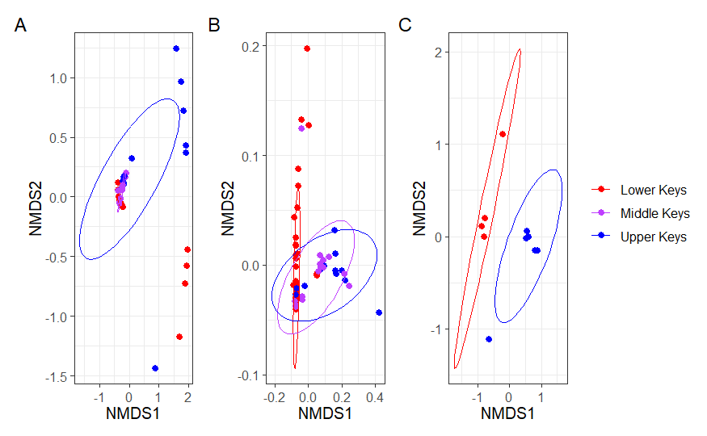

```r
Fig2
```

It says probable convergence error, but the ordinate() results all worked and the stress values are good.

## betadisper

```r
par(mfrow = c(1, 2),family="Times New Roman")
p<-psnoout # nooutlier dataset
sampledf<-data.frame(sample_data(p))
sampledf$Region <- as.factor(sampledf$Region)
d_mat<-phyloseq::distance(p, "bray")
g_mod<-with(sampledf,betadisper(d_mat,Region))
#boxplot(g_mod)
mod.tukey<-TukeyHSD(g_mod)
print(mod.tukey)
```

```
  Tukey multiple comparisons of means
    95% family-wise confidence level

Fit: aov(formula = distances ~ group, data = df)

$group
                             diff          lwr        upr     p adj
Middle Keys-Lower Keys 0.01604373 -0.008499038 0.04058650 0.2661650
Upper Keys-Lower Keys  0.03274867  0.006907602 0.05858974 0.0095002
Upper Keys-Middle Keys 0.01670494 -0.013557021 0.04696690 0.3863698
```

```r
labels <- multcompLetters(mod.tukey$group[, "p adj"])$Letters # Fix the order of the labels
labels <- labels[order(names(labels))]
bp<-boxplot(g_mod, ylim = c(0,.25), xlab=" ",cex.lab=1.5,cex.axis=1.2)
text( x=c(1:3),y=bp$stats[nrow(bp$stats),] + 0.05, labels,col="red",cex=1.5) #add labels
```

```r
title(outer=TRUE,main="A",cex.main=1.5,line=-1.7,adj=0.01)
gmod_noout<-g_mod

p<-psout # outlier dataset
sampledf<-data.frame(sample_data(p))
sampledf$Region <- as.factor(sampledf$Region)
d_mat<-phyloseq::distance(p, "bray")
g_mod<-with(sampledf,betadisper(d_mat,Region))
#boxplot(g_mod)
anova(g_mod)
```

```
Analysis of Variance Table

Response: Distances
          Df  Sum Sq  Mean Sq F value Pr(>F)
Groups     1 0.03757 0.037571  0.6572  0.441
Residuals  8 0.45735 0.057169
```

```r
bp<-boxplot(g_mod, ylim = c(0,.85), xlab=" ",cex.lab=1.5,cex.axis=1.2,ylab="")
```

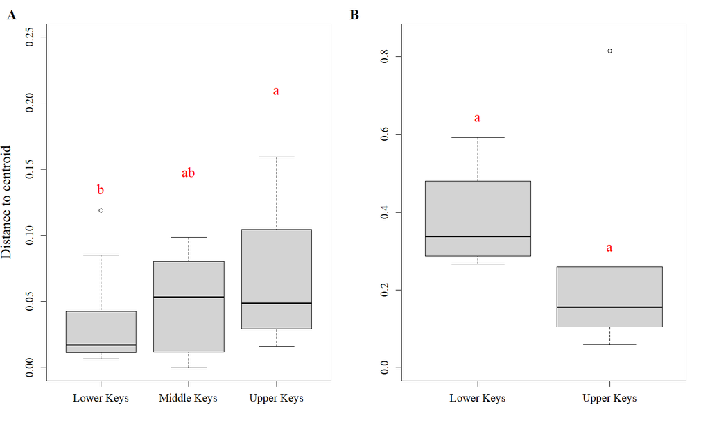

```r
text( x=c(1:3),y=bp$stats[nrow(bp$stats),] + 0.05, "a",col="red",cex=1.5) #add labels
title(outer=TRUE,main="B",cex.main=1.5,line=-1.7,adj=.5)
```

```r
gmod_out<-g_mod
```

…Same but now prettier.

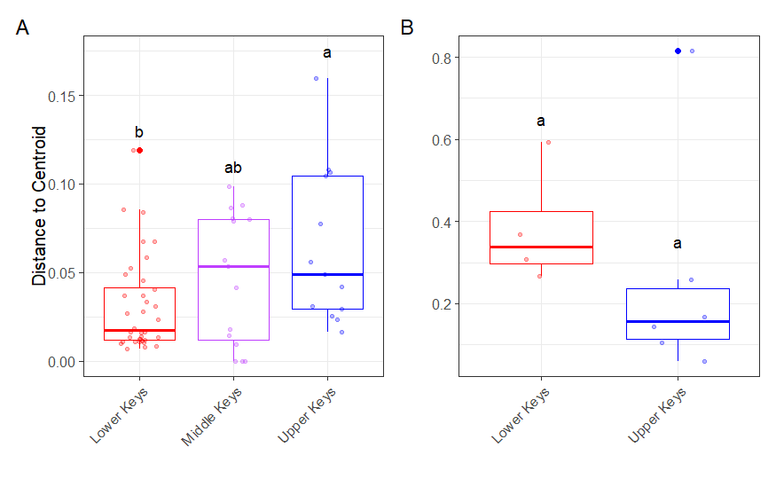

```r
DF_noout <- data.frame(group = gmod_noout$group, distances = gmod_noout$distances)
beta_noout<-DF_noout%>%ggplot(aes(group,distances,color=group)) +
  geom_boxplot() +
  geom_point(aes(color = group), position = position_jitter(width=.2, height=0), size = 1,alpha=0.3) +
  theme_bw()+
  xlab("") +
  theme(legend.position="none")+
  theme(text = element_text(size=12))+
  ylab("Distance to Centroid")  +
  theme(axis.text.x = element_text(angle = 45,hjust=1)) +
  theme(strip.text.x = element_text(size = 12))+
  scale_colour_manual(values=c("Lower Keys" = "red", "Middle Keys" = "darkorchid1", "Upper Keys" = "blue"))+ theme(text = element_text(family = "Times New Roman",size=12))+
  annotate("text", x = 1, y=.13, label = "b")+
  annotate("text", x = 2, y=.11, label = "ab")+
  annotate("text", x = 3, y=.175, label = "a")

DF_out <- data.frame(group = gmod_out$group, distances = gmod_out$distances)
beta_out<-DF_out%>%ggplot(aes(group,distances,color=group)) +
  geom_boxplot() +
  geom_point(aes(color = group), position = position_jitter(width=.2, height=0), size = 1,alpha=0.3) +
  theme_bw()+
  xlab("") +
  theme(legend.position="none")+
  theme(text = element_text(size=12))+
  ylab("")  +
  theme(axis.text.x = element_text(angle = 45,hjust=1)) +
  theme(strip.text.x = element_text(size = 12))+
  scale_colour_manual(values=c("Lower Keys" = "red", "Middle Keys" = "darkorchid1", "Upper Keys" = "blue"))+ theme(text = element_text(family = "Times New Roman",size=12))+
  annotate("text", x = 1, y=.65, label = "a")+
  annotate("text", x = 2, y=.35, label = "a")

Fig4 <- beta_noout +beta_out + plot_annotation(tag_levels="A")+plot_layout(guides='collect')
Fig4
```

```r
#ggsave("Figure4.png", plot = Fig4, width = 20, height = 10, units = "cm", dpi = 300)
```

Now the full dataset betadisper analysis:

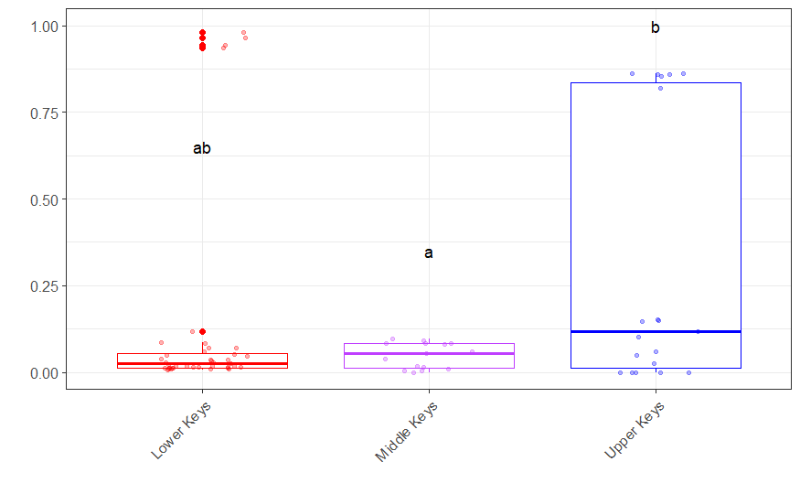

## Visualizing relative abundances

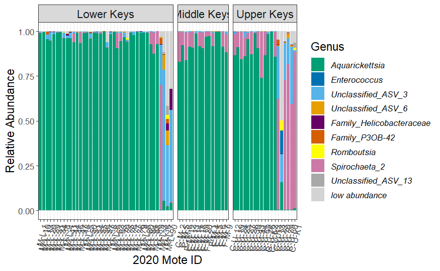

## Alpha Diversity

### calculate full dataset diversity measures

```r
myalphamets<-function(TEST){
  asvnew<-as.matrix((data.frame(otu_table(TEST))))
  samdf<-data.frame(sample_data(TEST))
  rich1 <- specnumber(asvnew)#calculates richness from css
  length(rich1)
  shannon1 <- vegan::diversity(asvnew,"shannon")
  length(shannon1)
  invsimp1 <- vegan::diversity(asvnew, "inv")
  length(invsimp1)
  alpha_coral <- data.frame()
  alpha_coral <- cbind(rich1, shannon1, invsimp1,samdf)
  alpha_coral <- rownames_to_column(alpha_coral, var = "id")
  alpha_coral <- data.frame(alpha_coral) #back to dataframe from matrix
  return(alpha_coral)
}
full_alpha<-myalphamets(ps)
out_alpha<-myalphamets(psout)
noout_alpha<-myalphamets(psnoout)
```

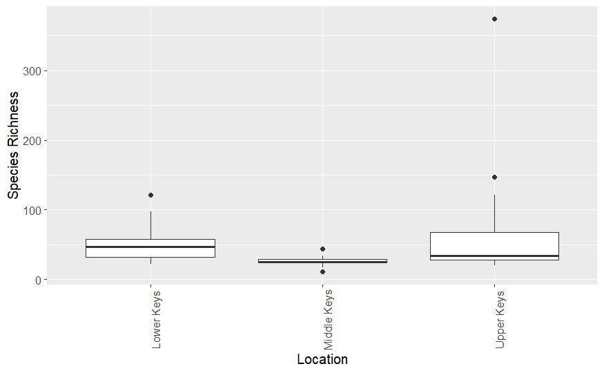

```r
full_ric <- full_alpha %>% ggplot(aes(Region,rich1)) +
  geom_boxplot() +
  xlab("Location") +
  theme(legend.position="none")+
  theme(text = element_text(size=12))+
  ylab("Species Richness")  +
  theme(axis.text.x = element_text(angle = 90)) +
  theme(legend.text=element_text(size=12), legend.position = "bottom",text = element_text(size=12),strip.text= element_text(size=12)) +
  #
  #facet_grid(~Outlier,space="free_x",scales="free_x",drop=TRUE) +
  theme(strip.text.x = element_text(size = 8))
full_ric
```

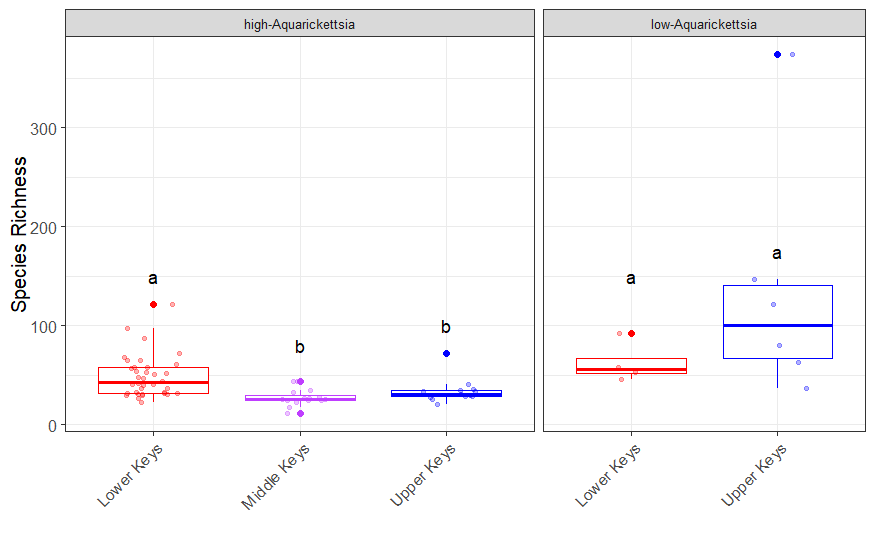

```r
full_alpha$Outlier<-factor(full_alpha$Outlier,levels=c("No","Yes"),labels=c("No"="high-Aquarickettsia","Yes"="low-Aquarickettsia"))
ric_ann_text<-data.frame(Region=c("Lower Keys","Middle Keys","Upper Keys","Lower Keys","Upper Keys"),rich1=c(150,80,100,150,175),Outlier=c("high-Aquarickettsia","high-Aquarickettsia","high-Aquarickettsia","low-Aquarickettsia","low-Aquarickettsia"),label=c("a","b","b","a","a"))

ric <- full_alpha %>% ggplot(aes(Region,rich1,color=Region)) +
  geom_boxplot() +
  geom_point(aes(color = Region), position = position_jitter(width=.2, height=0), size = 1,alpha=0.3) +
  theme_bw()+
  xlab("") +
  theme(legend.position="none")+
  theme(text = element_text(size=12))+
  ylab("Species Richness")  +
  theme(axis.text.x = element_text(angle = 45,hjust=1)) +
  facet_grid(~Outlier,space="free_x",scales="free_x",drop=TRUE) +
  theme(strip.text.x = element_text(size = 8))+
  scale_colour_manual(values=c("Lower Keys" = "red", "Middle Keys" = "darkorchid1", "Upper Keys" = "blue"))+
  theme(text = element_text(family = "Times New Roman",size=12))+
  geom_text(data = ric_ann_text,label=ric_ann_text$label,color="black")
ric
```

```r
# outliers are not sig dif by region
#
#rich no out  a, b, b
#shannon no out a, ab, b
```

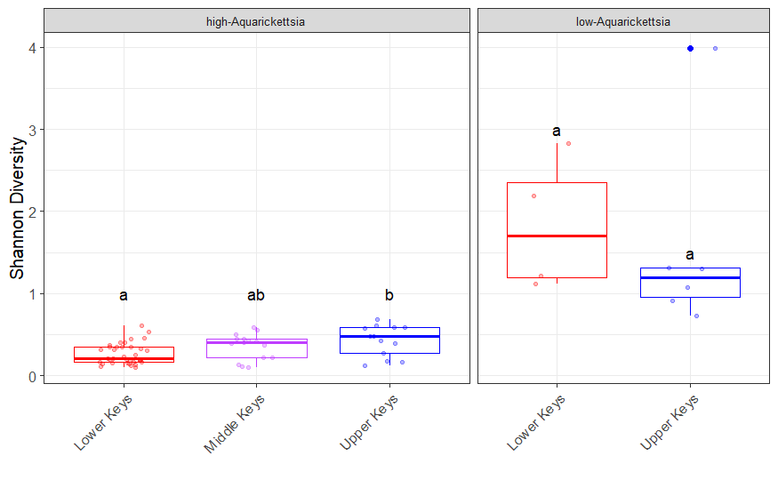

```r
div_ann_text<-data.frame(Region=c("Lower Keys","Middle Keys","Upper Keys","Lower Keys","Upper Keys"),shannon1=c(1,1,1,3,1.5),Outlier=c("high-Aquarickettsia","high-Aquarickettsia","high-Aquarickettsia","low-Aquarickettsia","low-Aquarickettsia"),label=c("a","ab","b","a","a"))

div <- full_alpha %>% ggplot(aes(Region,shannon1,color=Region)) +
  geom_boxplot() +
  geom_point(aes(color = Region), position = position_jitter(width=.2, height=0), size = 1,alpha=0.3) +
  theme_bw()+
  xlab("") +
  theme(legend.position="none")+
  theme(text = element_text(size=12))+
  ylab("Shannon Diversity")  +
  theme(axis.text.x = element_text(angle = 45,hjust=1)) +
  facet_grid(~Outlier,space="free_x",scales="free_x",drop=TRUE) +
  theme(strip.text.x = element_text(size = 8))+
  scale_colour_manual(values=c("Lower Keys" = "red", "Middle Keys" = "darkorchid1", "Upper Keys" = "blue"))+theme(text = element_text(family = "Times New Roman",size=12))+
  geom_text(data = div_ann_text,label=div_ann_text$label,color="black")
div
```

```r
#outliers are not sig dif by region
```

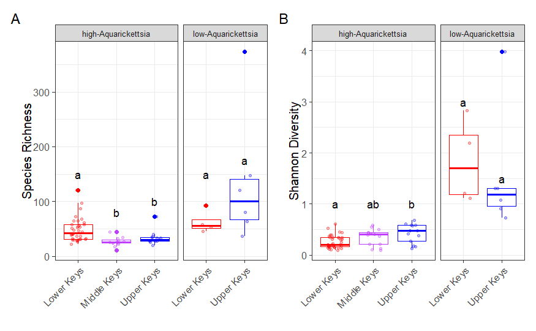

```r
fig5<-ric+div+plot_annotation(tag_levels="A")+plot_layout(guides='collect')
fig5
```

```r
#ggsave("Figure5.png", plot = fig5, width = 20, height = 10, units = "cm", dpi = 300)
```

#### Stats on Alpha Diversity

```r
print("full dataset")
```

```
[1] "full dataset"
```

```r
kruskal.test(rich1~Region,data=full_alpha)
```

```
    Kruskal-Wallis rank sum test

data:  rich1 by Region
Kruskal-Wallis chi-squared = 19.138, df = 2, p-value = 6.987e-05
```

```r
print("outlier dataset")
```

```
[1] "outlier dataset"
```

```r
kruskal.test(rich1~Region,data=out_alpha)
```

```
    Kruskal-Wallis rank sum test

data:  rich1 by Region
Kruskal-Wallis chi-squared = 1.6364, df = 1, p-value = 0.2008
```

```r
print("no outlier dataset")
```

```
[1] "no outlier dataset"
```

```r
kruskal.test(rich1~Region,data=noout_alpha)
```

```
    Kruskal-Wallis rank sum test

data:  rich1 by Region
Kruskal-Wallis chi-squared = 21.03, df = 2, p-value = 2.713e-05
```

```r
print("out vs no out")
```

```
[1] "out vs no out"
```

```r
kruskal.test(rich1~Outlier,data=full_alpha)
```

```
    Kruskal-Wallis rank sum test

data:  rich1 by Outlier
Kruskal-Wallis chi-squared = 14.173, df = 1, p-value = 0.0001667
```

```r
print("full dataset")
```

```
[1] "full dataset"
```

```r
kruskal.test(shannon1~Region,data=full_alpha)
```

```
    Kruskal-Wallis rank sum test

data:  shannon1 by Region
Kruskal-Wallis chi-squared = 12.092, df = 2, p-value = 0.002368
```

```r
print("outlier dataset")
```

```
[1] "outlier dataset"
```

```r
kruskal.test(shannon1~Region,data=out_alpha)
```

```
    Kruskal-Wallis rank sum test

data:  shannon1 by Region
Kruskal-Wallis chi-squared = 0.72727, df = 1, p-value = 0.3938
```

```r
print("no outlier dataset")
```

```
[1] "no outlier dataset"
```

```r
kruskal.test(shannon1~Region,data=noout_alpha)
```

```
    Kruskal-Wallis rank sum test

data:  shannon1 by Region
Kruskal-Wallis chi-squared = 9.5535, df = 2, p-value = 0.008423
```

```r
print("out vs no out")
```

```
[1] "out vs no out"
```

```r
kruskal.test(shannon1~Outlier,data=full_alpha)
```

```
    Kruskal-Wallis rank sum test

data:  shannon1 by Outlier
Kruskal-Wallis chi-squared = 25.6, df = 1, p-value = 4.2e-07
```

#### posthoc richness

```r
richpairkruskal<-function(alp){
  sampledf<-data.frame(sample_data(ps))
  sampledf$Region<-as.factor(sampledf$Region)
  region.list<-levels(sampledf$Region)
  region.list
  aovresults<-c()
  pvals<-c()
  locations<-c()
  for (i in 1:length(region.list)){
    region.leftout<-region.list[i]
    alph_sub<-subset(alp,Region!=region.leftout) #instead of subset_samples use a subset() for the dataframe you are working with
    #d.sub<-phyloseq::distance(ps_sub, "bray") # won't need this for kruskal
    #df.new<-subset(sampledf,subset=Region!=region.leftout) # won't need this either
    PERM<-kruskal.test(rich1~Region,alph_sub) #change to kruskal
    print(PERM)
    pvals<-c(pvals,PERM$'p.value') #this will change. run a kruskal and save the output to do str(output) to see what it call's the pvalues that it outputs.
    #aovresults<-rbind(aovresults,PERM$aov.tab)
    loc.sub<-region.list[-i]
    locations<-rbind(locations,c(loc.sub))
  }
  aovresults
  combinedtest<-cbind(locations,pvals)
  mult_perm<-data.frame(combinedtest)
  mult_perm
  mult_perm$pvaladj<-p.adjust(mult_perm$pvals,method="bonferroni")
  mult_perm
}
fullrichpair<-richpairkruskal(full_alpha)
```

```
    Kruskal-Wallis rank sum test

data:  rich1 by Region
Kruskal-Wallis chi-squared = 9.0205, df = 1, p-value = 0.00267


    Kruskal-Wallis rank sum test

data:  rich1 by Region
Kruskal-Wallis chi-squared = 1.096, df = 1, p-value = 0.2951


    Kruskal-Wallis rank sum test

data:  rich1 by Region
Kruskal-Wallis chi-squared = 18.835, df = 1, p-value = 1.426e-05
```

```r
fullrichpair
```

| V1 | V2 | pvals | pvaladj |
| --- | --- | --- | --- |
| Middle Keys | Upper Keys | 0.0026696861946576 | 8.009059e-03 |
| Lower Keys | Upper Keys | 0.295148335294891 | 8.854450e-01 |
| Lower Keys | Middle Keys | 1.42558585951368e-05 | 4.276758e-05 |

```r
nooutrichpair<-richpairkruskal(noout_alpha)
```

```
    Kruskal-Wallis rank sum test

data:  rich1 by Region
Kruskal-Wallis chi-squared = 4.0308, df = 1, p-value = 0.04468


    Kruskal-Wallis rank sum test

data:  rich1 by Region
Kruskal-Wallis chi-squared = 7.6441, df = 1, p-value = 0.005696


    Kruskal-Wallis rank sum test

data:  rich1 by Region
Kruskal-Wallis chi-squared = 17.033, df = 1, p-value = 3.674e-05
```

```r
nooutrichpair
```

| V1 | V2 | pvals | pvaladj |
| --- | --- | --- | --- |
| Middle Keys | Upper Keys | 0.044675998562569 | 0.1340279957 |
| Lower Keys | Upper Keys | 0.00569573375042984 | 0.0170872013 |
| Lower Keys | Middle Keys | 3.67445759182583e-05 | 0.0001102337 |

```r
###NO OUTLIERS INCLUDED SINCE ONLY 2 GROUPS (LOW AND UP)
```

#rich no out a, b, b #shannon no out a, ab, b

#### posthoc shannon

```r
shanpairkruskal<-function(alp){
  sampledf<-data.frame(sample_data(ps))
  sampledf$Region<-as.factor(sampledf$Region)
  region.list<-levels(sampledf$Region)
  region.list
  aovresults<-c()
  pvals<-c()
  locations<-c()
  for (i in 1:length(region.list)){
    region.leftout<-region.list[i]
    alph_sub<-subset(alp,Region!=region.leftout) #instead of subset_samples use a subset() for the dataframe you are working with
    #d.sub<-phyloseq::distance(ps_sub, "bray") # won't need this for kruskal
    #df.new<-subset(sampledf,subset=Region!=region.leftout) # won't need this either
    PERM<-kruskal.test(shannon1~Region,alph_sub) #change to kruskal
    print(PERM)
    pvals<-c(pvals,PERM$'p.value') #this will change. run a kruskal and save the output to do str(output) to see what it call's the pvalues that it outputs.
    #aovresults<-rbind(aovresults,PERM$aov.tab)
    loc.sub<-region.list[-i]
    locations<-rbind(locations,c(loc.sub))
  }
  aovresults
  combinedtest<-cbind(locations,pvals)
  mult_perm<-data.frame(combinedtest)
  mult_perm
  mult_perm$pvaladj<-p.adjust(mult_perm$pvals,method="bonferroni")
  mult_perm
}
fullshanpair<-shanpairkruskal(full_alpha)
```

```
    Kruskal-Wallis rank sum test

data:  shannon1 by Region
Kruskal-Wallis chi-squared = 6.3233, df = 1, p-value = 0.01192


    Kruskal-Wallis rank sum test

data:  shannon1 by Region
Kruskal-Wallis chi-squared = 10.213, df = 1, p-value = 0.001395


    Kruskal-Wallis rank sum test

data:  shannon1 by Region
Kruskal-Wallis chi-squared = 1.7004, df = 1, p-value = 0.1922
```

```r
fullshanpair
```

| V1 | V2 | pvals | pvaladj |
| --- | --- | --- | --- |
| Middle Keys | Upper Keys | 0.0119161110521068 | 0.035748333 |
| Lower Keys | Upper Keys | 0.00139462100907179 | 0.004183863 |
| Lower Keys | Middle Keys | 0.192241277240473 | 0.576723832 |

```r
nooutshanpair<-shanpairkruskal(noout_alpha)
```

```
    Kruskal-Wallis rank sum test

data:  shannon1 by Region
Kruskal-Wallis chi-squared = 1.6048, df = 1, p-value = 0.2052


    Kruskal-Wallis rank sum test

data:  shannon1 by Region
Kruskal-Wallis chi-squared = 7.2621, df = 1, p-value = 0.007043


    Kruskal-Wallis rank sum test

data:  shannon1 by Region
Kruskal-Wallis chi-squared = 4.1885, df = 1, p-value = 0.0407
```

```r
nooutshanpair
```

| V1 | V2 | pvals | pvaladj |
| --- | --- | --- | --- |
| Middle Keys | Upper Keys | 0.205227899681961 | 0.61568370 |
| Lower Keys | Upper Keys | 0.00704268042781886 | 0.02112804 |
| Lower Keys | Middle Keys | 0.0407000162514542 | 0.12210005 |

```r
###NO OUTLIERS INCLUDED SINCE ONLY 2 GROUPS (LOW AND UP)
```

#### Corncob

Use unrarified data

```r
sample_data(ps_acer_norare)$Outlier<-sample_data(ps_acer)$Outlier
ps_noout_nr<-subset_samples(ps_acer_norare,Outlier!="Yes")
ps_noout_nr
```

```
phyloseq-class experiment-level object
otu_table()   OTU Table:         [ 1290 taxa and 64 samples ]
sample_data() Sample Data:       [ 64 samples by 13 sample variables ]
tax_table()   Taxonomy Table:    [ 1290 taxa by 7 taxonomic ranks ]
```

```r
ps_noout
```

```
phyloseq-class experiment-level object
otu_table()   OTU Table:         [ 1195 taxa and 64 samples ]
sample_data() Sample Data:       [ 64 samples by 16 sample variables ]
tax_table()   Taxonomy Table:    [ 1195 taxa by 7 taxonomic ranks ]
```

```r
ps_out_nr<-subset_samples(ps_acer_norare,Outlier=="Yes")
ps_out_nr
```

```
phyloseq-class experiment-level object
otu_table()   OTU Table:         [ 1290 taxa and 10 samples ]
sample_data() Sample Data:       [ 10 samples by 13 sample variables ]
tax_table()   Taxonomy Table:    [ 1290 taxa by 7 taxonomic ranks ]
```

```r
set.seed(1)
da_analysis_nr<-differentialTest(formula = ~Region,
                              phi.formula = ~Region,
                              formula_null = ~1,
                              phi.formula_null = ~1,
                              test="Wald",
                              boot=FALSE,
                              data=ps_noout_nr,
                              fdr_cutoff = 0.05)
```

```r
da_analysis_nr
```

```
Object of class differentialTest

$p: p-values
$p_fdr: FDR-adjusted p-values
$significant_taxa: taxa names of the statistically significant taxa
$significant_models: model summaries of the statistically significant taxa
$all_models: all model summaries
$restrictions_DA: covariates tested for differential abundance
$restrictions_DV: covariates tested for differential variability
$discriminant_taxa_DA: taxa for which at least one covariate associated with the abundance was perfectly discriminant
$discriminant_taxa_DV: taxa for which at least one covariate associated with the dispersion was perfectly discriminant

plot( ) to see a plot of tested coefficients from significant taxa
```

```r
da_analysis_nr$significant_models
```

```
[[1]]

Call:
bbdml(formula = formula_i, phi.formula = phi.formula, data = data_i,
    link = link, phi.link = phi.link, inits = inits)


Coefficients associated with abundance:
                  Estimate Std. Error t value Pr(>|t|)
(Intercept)         3.0580     0.1111  27.520  < 2e-16 ***
RegionMiddle Keys  -0.6714     0.2220  -3.024 0.003712 **
RegionUpper Keys   -1.0008     0.2409  -4.154 0.000109 ***
---
Signif. codes:  0 ‘***’ 0.001 ‘**’ 0.01 ‘*’ 0.05 ‘.’ 0.1 ‘ ’ 1


Coefficients associated with dispersion:
                  Estimate Std. Error t value Pr(>|t|)
(Intercept)        -3.9413     0.2431 -16.212   <2e-16 ***
RegionMiddle Keys   0.8337     0.4464   1.867   0.0669 .
RegionUpper Keys    1.1866     0.4666   2.543   0.0137 *
---
Signif. codes:  0 ‘***’ 0.001 ‘**’ 0.01 ‘*’ 0.05 ‘.’ 0.1 ‘ ’ 1


Log-likelihood: -677.68

[[2]]

Call:
bbdml(formula = formula_i, phi.formula = phi.formula, data = data_i,
    link = link, phi.link = phi.link, inits = inits)


Coefficients associated with abundance:
                  Estimate Std. Error t value Pr(>|t|)
(Intercept)        -5.3812     0.2585 -20.818  < 2e-16 ***
RegionMiddle Keys   2.6331     0.4155   6.337 3.77e-08 ***
RegionUpper Keys    3.0380     0.4382   6.933 3.80e-09 ***
---
```

[output cut: 214 more lines]

```
RegionUpper Keys   -0.1218     0.4726  -0.258    0.797
---
Signif. codes:  0 ‘***’ 0.001 ‘**’ 0.01 ‘*’ 0.05 ‘.’ 0.1 ‘ ’ 1


Coefficients associated with dispersion:
                  Estimate Std. Error t value Pr(>|t|)
(Intercept)        -9.1530     0.3009 -30.415   <2e-16 ***
RegionMiddle Keys   1.2677     0.6250   2.028   0.0471 *
RegionUpper Keys    1.6116     0.6938   2.323   0.0237 *
---
Signif. codes:  0 ‘***’ 0.001 ‘**’ 0.01 ‘*’ 0.05 ‘.’ 0.1 ‘ ’ 1


Log-likelihood: -313.58
```

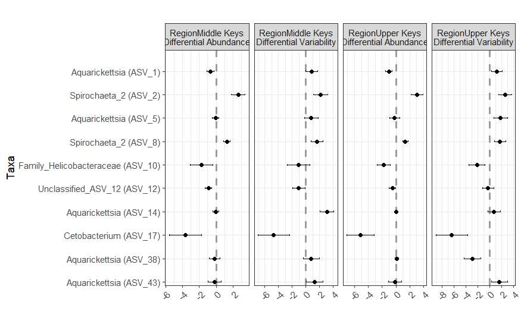

```r
plot(da_analysis_nr,level="Genus")
```

```r
da_analysis_out<-differentialTest(formula = ~Region,
                              phi.formula = ~Region,
                              formula_null = ~1,
                              phi.formula_null = ~1,
                              test="Wald",
                              boot=FALSE,
                              data=ps_out_nr,
                              fdr_cutoff = 0.05)
```

```r
da_analysis_out$significant_taxa
```

```
[1] "ASV_2"  "ASV_9"  "ASV_10" "ASV_21" "ASV_33" "ASV_35"
```

```r
da_analysis_out$significant_models
```

```
[[1]]

Call:
bbdml(formula = formula_i, phi.formula = phi.formula, data = data_i,
    link = link, phi.link = phi.link, inits = inits)


Coefficients associated with abundance:
                 Estimate Std. Error t value Pr(>|t|)
(Intercept)       -5.9324     0.3440 -17.247 2.43e-06 ***
RegionUpper Keys   5.7245     0.6197   9.237 9.09e-05 ***
---
Signif. codes:  0 ‘***’ 0.001 ‘**’ 0.01 ‘*’ 0.05 ‘.’ 0.1 ‘ ’ 1


Coefficients associated with dispersion:
                 Estimate Std. Error t value Pr(>|t|)
(Intercept)       -6.6982     0.7491  -8.941 0.000109 ***
RegionUpper Keys   6.6085     0.8777   7.530 0.000284 ***
---
Signif. codes:  0 ‘***’ 0.001 ‘**’ 0.01 ‘*’ 0.05 ‘.’ 0.1 ‘ ’ 1


Log-likelihood: -98.781

[[2]]

Call:
bbdml(formula = formula_i, phi.formula = phi.formula, data = data_i,
    link = link, phi.link = phi.link, inits = inits)


Coefficients associated with abundance:
                 Estimate Std. Error t value Pr(>|t|)
(Intercept)       -11.440      1.189  -9.624  7.2e-05 ***
RegionUpper Keys    7.243      1.704   4.250  0.00538 **
---
Signif. codes:  0 ‘***’ 0.001 ‘**’ 0.01 ‘*’ 0.05 ‘.’ 0.1 ‘ ’ 1


```

[output cut: 92 more lines]

```
(Intercept)      -12.1626     0.8459 -14.378 7.09e-06 ***
RegionUpper Keys   6.3502     1.6586   3.829  0.00867 **
---
Signif. codes:  0 ‘***’ 0.001 ‘**’ 0.01 ‘*’ 0.05 ‘.’ 0.1 ‘ ’ 1


Coefficients associated with dispersion:
                 Estimate Std. Error t value Pr(>|t|)
(Intercept)       -12.275      2.798  -4.386  0.00464 **
RegionUpper Keys    8.996      3.199   2.812  0.03066 *
---
Signif. codes:  0 ‘***’ 0.001 ‘**’ 0.01 ‘*’ 0.05 ‘.’ 0.1 ‘ ’ 1


Log-likelihood: -30.348
```

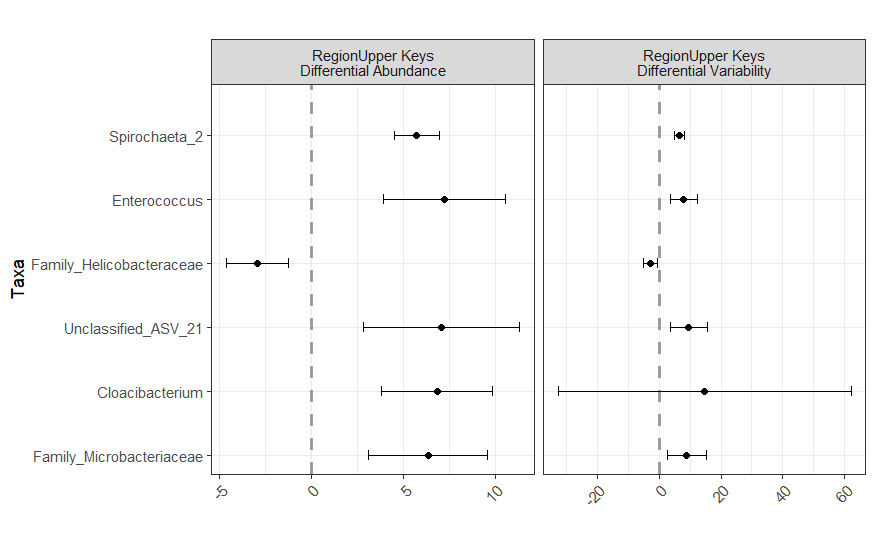

```r
plot(da_analysis_out,level="Genus")
```

```r
NA
NA
```

```r
#from Becker et al in review
#Write a function to extract the significant taxa and put it in a dataframe with a for loop so you can rearrange the levels of the taxa to make a nice ordered graph.
da_analysis_nr$significant_models[[2]]$coefficients
```

```
                       Estimate Std. Error    t value     Pr(>|t|)
mu.(Intercept)        -5.381168  0.2584879 -20.817871 1.357917e-28
mu.RegionMiddle Keys   2.633069  0.4155067   6.337008 3.768197e-08
mu.RegionUpper Keys    3.037966  0.4382151   6.932591 3.803706e-09
phi.(Intercept)       -4.501846  0.3199956 -14.068462 2.378884e-20
phi.RegionMiddle Keys  2.191590  0.5303006   4.132731 1.167592e-04
phi.RegionUpper Keys   2.615387  0.5470009   4.781321 1.232717e-05
```

```r
sigtaxto_df_2options <- function(daout, psobj,uporlow) {#2 or 3
  df.out <- c()
  for (i in 1:length(daout$significant_models)) { #from 1 to the number of significant taxa
  df.out = rbind(df.out, daout$significant_models[[i]]$coefficients[uporlow, 1:4])
  #bind the sig.mcav row with coefficient, std. error, t value, Pr thing. coefficients[2,] is the DA model output.
  }
  asv = as.vector(daout$significant_taxa) #get significant ASVs
  Class = as.vector(otu_to_taxonomy(data = psobj, daout$significant_taxa, level = c("Class"))) #isolate class of significant Asvs
  Order = as.vector(otu_to_taxonomy(data = psobj, daout$significant_taxa, level = c("Order"))) #isolate order of significant ASVs
  Family = as.vector(otu_to_taxonomy(data = psobj, daout$significant_taxa, level = c("Family"))) #isolate family of significant ASVs
  Family.fix = ifelse(Family == "", "unclassified", Family) #replace empty values with "unclassified"
  Genus = as.vector(otu_to_taxonomy(data = psobj, daout$significant_taxa, level = c("Genus"))) #isolate Genus of singnificant ASVs
  Genus.fix = ifelse(Genus == "", "unclassified", Genus) #replace empty values with "unclassified"

  df.bind <- as.data.frame(cbind(df.out, asv, Class, Order, Family.fix, Genus.fix)) #bind taxonomic info together, making sure to use the vectors with "unclassified"
  df.bind$asvgenus <- paste0(df.bind$Genus.fix, " (", df.bind$asv, ")") #make a concatenated column of ASV and Genus.
  colnames(df.bind) <- c("Estimate", "StdError", "tvalue", "Pr", "asv", "Class", "Order", "Family", "Genus", "asvtaxa")
  df.bind$Estimate = as.numeric(as.character(df.bind$Estimate)) #estimate column should be numeric
  df.bind$StdError = as.numeric(as.character(df.bind$StdError)) #stderror column should be numeric

  return(df.bind)
}


mid.forgraph <- sigtaxto_df_2options(da_analysis_nr, ps_noout_nr,2) #make a df of the corncob output and the taxonomy
#Change the levels of the $asvtaxa row so that it reorders the plot by decreasing coefficients
#mid.forgraph <- mid.forgraph[order(mid.forgraph$Estimate), ]
mid.forgraph$asvtaxa <- factor(mid.forgraph$asvtaxa, levels = as.vector(mid.forgraph$asvtaxa))


up.forgraph <- sigtaxto_df_2options(da_analysis_nr, ps_noout_nr,3) #make a df of the corncob output and the taxonomy
#Change the levels of the $asvtaxa row so that it reorders the plot by decreasing coefficients
#up.forgraph <- up.forgraph[order(up.forgraph$Estimate), ]
up.forgraph$asvtaxa <- factor(up.forgraph$asvtaxa, levels = as.vector(up.forgraph$asvtaxa))

mycolors <- c("#1B9E77","#CC79A7","#660066","yellow","red","blue")
names(mycolors)<-c("Aquarickettsia","Spirochaeta_2","Family_Helicobacteraceae","Romboutsia","Cetobacterium","Unclassified_ASV_12")
mycolors
```

```
          Aquarickettsia            Spirochaeta_2 Family_Helicobacteraceae
               "#1B9E77"                "#CC79A7"                "#660066"
              Romboutsia            Cetobacterium      Unclassified_ASV_12
                "yellow"                    "red"                   "blue"
```

```
geom_path: Each group consists of only one observation. Do you need to adjust the group
aesthetic?
```

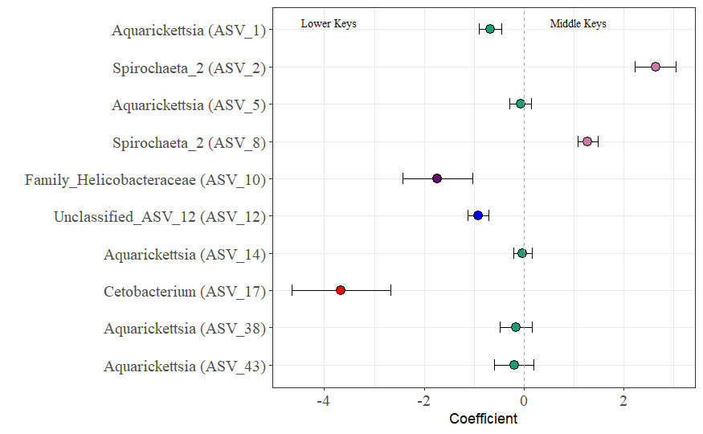

```r
lowmid<-ggplot(mid.forgraph, aes(x = asvtaxa, y = Estimate, fill = Genus)) +
  geom_errorbar(aes(ymin = Estimate-StdError, ymax = Estimate+StdError), color = "black", width = .3, position=position_dodge(.9)) +
  geom_point(size = 3, pch = 21) +
  scale_x_discrete(limits = rev(levels(mid.forgraph$asvtaxa))) +
  scale_fill_manual(values = mycolors) +
  geom_line() +
  coord_flip() +
  theme_bw() +
  labs(x = " ", y = "Coefficient",family="Times New Roman") +
  geom_hline(yintercept = 0, linetype = "dashed", color = "darkgray")+
  theme(legend.position = "none",axis.text.x=element_text(family="Times New Roman",size=12),axis.text.y=element_text(family="Times New Roman",size=12))+
  annotate("text",x=10.2,y=-3.9,label="Lower Keys",family="Times New Roman",size=3)+
  annotate("text",x=10.2,y=1.1,label="Middle Keys",family="Times New Roman",size=3)
lowmid
```

```
geom_path: Each group consists of only one observation. Do you need to adjust the group
aesthetic?
```

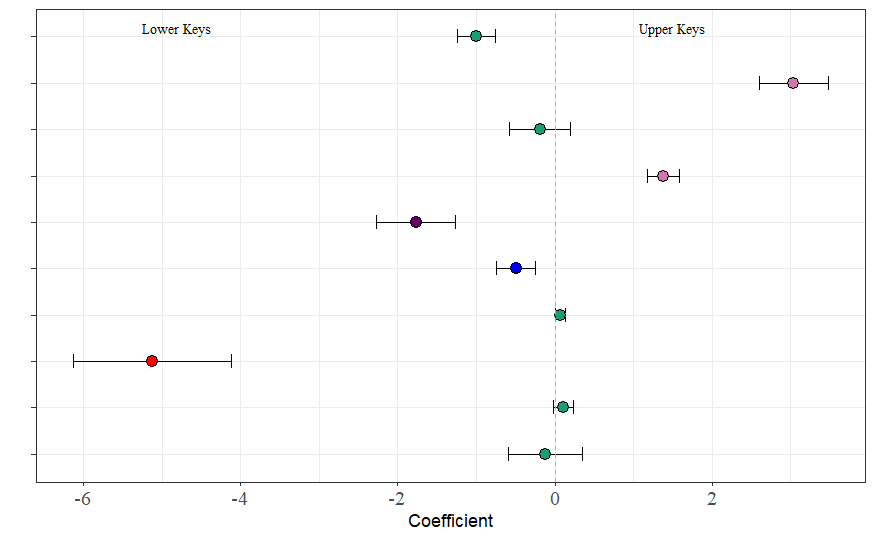

```r
lowup<-ggplot(up.forgraph, aes(x = asvtaxa, y = Estimate, fill = Genus)) +
  geom_errorbar(aes(ymin = Estimate-StdError, ymax = Estimate+StdError), color = "black", width = .3, position=position_dodge(.9)) +
  geom_point(size = 3, pch = 21) +
  scale_x_discrete(limits = rev(levels(up.forgraph$asvtaxa))) +
  scale_fill_manual(values = mycolors) +
  geom_line() +
  coord_flip() +
  theme_bw() +
  labs(x = "", y = "Coefficient",family="Times New Roman") +
  geom_hline(yintercept = 0, linetype = "dashed", color = "darkgray")+theme(axis.text.y=element_blank(),legend.position="none",axis.text.x=element_text(family="Times New Roman",size=12))+
  annotate("text",x=10.2,y=-4.8,label="Lower Keys",family="Times New Roman",size=3)+
  annotate("text",x=10.2,y=1.5,label="Upper Keys",family="Times New Roman",size=3)
lowup
```

```r
out.forgraph <- sigtaxto_df_2options(da_analysis_out, ps_out_nr,2) #make a df of the corncob output and the taxonomy
```

[output not shown]

```
geom_path: Each group consists of only one observation. Do you need to adjust the
group aesthetic?
```

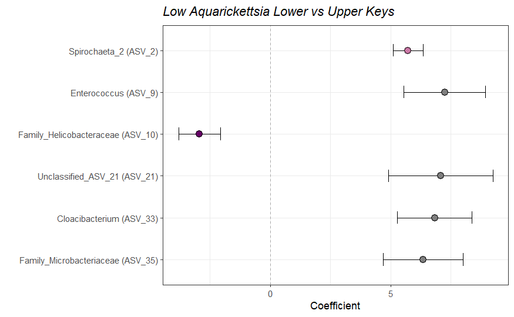

```r
(outcorn)
```

## bubble plot

```r
sample_variables(ps)
```

```
 [1] "Sample.ID"                                "Orig_geno_ID"
 [3] "X2020_Mote_ID"                            "Genotype"
 [5] "Outlier"                                  "sampling_date"
 [7] "Species"                                  "Lat"
 [9] "Long"                                     "Region"
[11] "collection_date"                          "Baums_MSAT_clonal_ID"
[13] "Proposed_pheno"                           "Date.Introduced.into.Nursery"
[15] "Max.Years.Spent.in.Nursery"               "Max.Years.Spent.from.Original.Collection"
[17] "Region.Outlier"
```

```r
variable1 = as.character(get_variable(ps, "Region"))
variable2 = as.character(get_variable(ps, "Outlier"))

sample_data(ps)$Region.Outlier <- mapply(paste, variable1, variable2, sep = " ")
levels(as.factor(sample_data(ps)$Region.Outlier))
```

```
[1] "Lower Keys No"  "Lower Keys Yes" "Middle Keys No" "Upper Keys No"  "Upper Keys Yes"
```

```r
physeq.f<-merge_samples(ps,"Region.Outlier")
sample_data(physeq.f)
```

```
Sample Data:        [5 samples by 17 sample variables]:
```

|  | Sample.ID | Orig_geno_ID | X2020_Mote_ID | Genotype | Outlier | sampling_date | Species | Lat | Long | Region | collection_date | Baums_MSAT_clonal_ID | Proposed_pheno | Date.Introduced.into.Nursery | Max.Years.Spent.in.Nursery | Max.Years.Spent.from.Original.Collection | Region.Outlier |
| --- | --- | --- | --- | --- | --- | --- | --- | --- | --- | --- | --- | --- | --- | --- | --- | --- | --- |
| Lower Keys No | NA | 47.97222 | NA | 48.09083 | NA | NA | NA | 24.54814 | -81.47313 | NA | NA | NA | NA | NA | 8.255667 | 8.255833 | NA |
| Lower Keys Yes | NA | 34.00000 | NA | 34.10000 | NA | NA | NA | 24.55937 | -81.47254 | NA | NA | NA | NA | NA | 7.080000 | 7.080000 | NA |
| Middle Keys No | NA | NA | NA | NA | NA | NA | NA | 24.71336 | -80.91776 | NA | NA | NA | NA | NA | NA | 8.310448 | NA |
| Upper Keys No | NA | NA | NA | NA | NA | NA | NA | 24.92538 | -80.52721 | NA | NA | NA | NA | NA | 3.474231 | 11.128769 | NA |
| Upper Keys Yes | NA | NA | NA | NA | NA | NA | NA | 24.98884 | -80.44639 | NA | NA | NA | NA | NA | 2.949167 | 10.278500 | NA |

```r
physeq.f.ra <- transform_sample_counts(physeq.f, function(x) x*100/sum(x))
#look at graces code and do mean!
#want ASV_1, ASV_2, ASV_5, ASV_8, ASV_10,ASV_12, ASV_14, ASV_17, ASV_38, ASV_43
p<-physeq.f.ra

o<-otu_table(p)
propData <- as.data.frame(o)
sample_data(p)$Region.Outlier<-rownames(sample_data(p))
t<-data.frame(cbind(levels(as.factor(sample_data(p)$Region.Outlier))))
t <-cbind(t,propData$ASV_1,propData$ASV_2,propData$ASV_5,propData$ASV_8,propData$ASV_10,propData$ASV_12, propData$ASV_14,propData$ASV_17,propData$ASV_38,propData$ASV_43)
colnames(t)<-c("Region.Outlier","ASV_1", "ASV_2", "ASV_5", "ASV_8", "ASV_10","ASV_12", "ASV_14", "ASV_17", "ASV_38","ASV_43")
highlow<-c("High-Aquarickettsia","Low-Aquarickettsia","High-Aquarickettsia","High-Aquarickettsia","Low-Aquarickettsia")
region<-c("Lower Keys","Lower Keys","Middle Keys","Upper Keys","Upper Keys")
t<-cbind(highlow,region,t)
pcm = melt(t, id.vars = c("Region.Outlier","region","highlow")) #convert data frame from a "wide" format to a "long" format

mycolors2 <- c("#1B9E77","#CC79A7","#1B9E77","#CC79A7","#660066","blue","#1B9E77","red","#1B9E77","#1B9E77")
names(mycolors2)<-levels(pcm$variable)
mycolors2
```

```
    ASV_1     ASV_2     ASV_5     ASV_8    ASV_10    ASV_12    ASV_14    ASV_17    ASV_38
"#1B9E77" "#CC79A7" "#1B9E77" "#CC79A7" "#660066"    "blue" "#1B9E77"     "red" "#1B9E77"
   ASV_43
"#1B9E77"
```

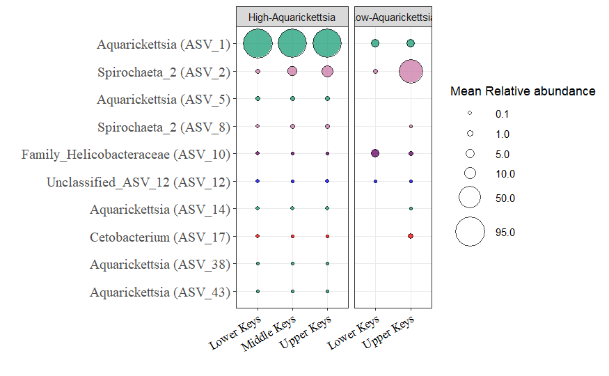

```r
levels(pcm$variable)<-c("Aquarickettsia (ASV_1)","Spirochaeta_2 (ASV_2)","Aquarickettsia (ASV_5)","Spirochaeta_2 (ASV_8)","Family_Helicobacteraceae (ASV_10)","Unclassified_ASV_12 (ASV_12)","Aquarickettsia (ASV_14)","Cetobacterium (ASV_17)",'Aquarickettsia (ASV_38)',"Aquarickettsia (ASV_43)")
names(mycolors2)<-levels(pcm$variable)
xx<-ggplot(pcm, aes(x = region, y = variable,fill=variable)) +
  geom_point(aes(size = as.numeric(value)), alpha = 0.75, shape = 21) +
  scale_size_continuous(limits = c(0.00001, 100), range = c(1,12), breaks = c(.1,1,5,10,50,95)) +
  labs( x= "", y = "", size = "Mean Relative abundance", fill = "")  +
  theme(legend.key=element_blank()) +
  scale_fill_manual(values = mycolors2,guide=FALSE) +
  theme_bw()+
  scale_y_discrete(limits = rev(levels(pcm$variable)))+
  facet_grid(~highlow, scales = "free_x", space = "free_x")+
  theme(legend.position = "right", axis.text.y = element_text(family="Times New Roman", size = 12),axis.text.x = element_text(colour = "black", size = 10, angle = 30, hjust = 1,family="Times New Roman"))
xx
```

```
geom_path: Each group consists of only one observation. Do you need to adjust the group
aesthetic?
geom_path: Each group consists of only one observation. Do you need to adjust the group
aesthetic?
Warning: Removed 9 rows containing missing values (geom_point).
Warning: It is deprecated to specify `guide = FALSE` to remove a guide. Please use `guide = "none"` instead.
```

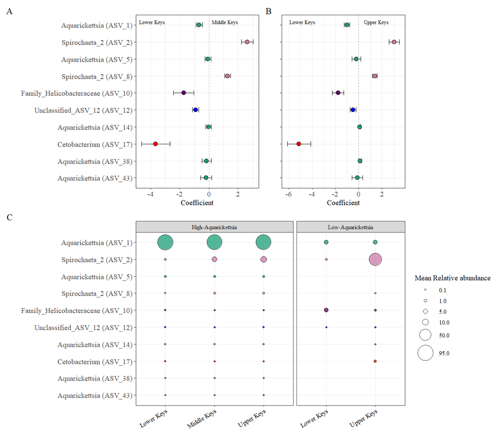

```r
fig6
```

## Temporal differences

### Time averages and such full data set

```r
dat<-data.frame(sample_data(ps))
mean(dat$Max.Years.Spent.in.Nursery,na.rm = TRUE)
```

```
[1] 6.087429
```

```r
mean(subset(dat,subset=Region!="Lower Keys")$Max.Years.Spent.in.Nursery,na.rm = TRUE)
```

```
[1] 3.3532
```

```r
mean(dat$Max.Years.Spent.from.Original.Collection,na.rm = TRUE)
```

```
[1] 8.87205
```

```r
median(dat$Max.Years.Spent.in.Nursery,na.rm = TRUE)
```

```
[1] 3.929
```

```r
median(dat$Max.Years.Spent.from.Original.Collection,na.rm = TRUE)
```

```
[1] 9.607
```

```r
range(dat$Max.Years.Spent.in.Nursery,na.rm = TRUE)
```

```
[1]  0.175 11.803
```

```r
range(dat$Max.Years.Spent.from.Original.Collection,na.rm = TRUE)
```

```
[1]  0.175 13.829
```

```r
sd(dat$Max.Years.Spent.in.Nursery,na.rm = TRUE)
```

```
[1] 3.398781
```

```r
sd(dat$Max.Years.Spent.from.Original.Collection,na.rm = TRUE)
```

```
[1] 3.030377
```

```r
std.error(dat$Max.Years.Spent.in.Nursery,na.rm = TRUE)
```

```
[1] 0.406232
```

```r
std.error(dat$Max.Years.Spent.from.Original.Collection,na.rm = TRUE)
```

```
[1] 0.3522741
```

## Time averages and such by region

```r
datlow <- data.frame(sample_data(ps_low))
datmid <- data.frame(sample_data(ps_mid))
 datup <- data.frame(sample_data(ps_up))
length(datlow$Sample.ID)
```

```
[1] 40
```

```r
length(datmid$Sample.ID)
```

```
[1] 15
```

```r
length(datup$Sample.ID)
```

```
[1] 19
```

```r
mean(datup$Max.Years.Spent.in.Nursery,na.rm = TRUE)
```

```
[1] 3.308421
```

```r
mean(datup$Max.Years.Spent.from.Original.Collection,na.rm = TRUE)
```

```
[1] 10.86026
```

```r
median(datup$Max.Years.Spent.in.Nursery,na.rm = TRUE)
```

```
[1] 3.496
```

```r
median(datup$Max.Years.Spent.from.Original.Collection,na.rm = TRUE)
```

```
[1] 11.521
```

```r
range(datmid$Max.Years.Spent.in.Nursery,na.rm = TRUE)
```

```
[1] 1.506 4.011
```

```r
range(datup$Max.Years.Spent.from.Original.Collection,na.rm = TRUE)
```

```
[1]  5.098 13.829
```

```r
sd(datup$Max.Years.Spent.in.Nursery,na.rm = TRUE)
```

```
[1] 0.8420978
```

```r
sd(datup$Max.Years.Spent.from.Original.Collection,na.rm = TRUE)
```

```
[1] 2.08284
```

```r
std.error(datup$Max.Years.Spent.in.Nursery,na.rm = TRUE)
```

```
[1] 0.1931905
```

```r
std.error(datup$Max.Years.Spent.from.Original.Collection,na.rm = TRUE)
```

```
[1] 0.4778363
```

```r
range(datlow$Max.Years.Spent.in.Nursery,na.rm=TRUE)
```

```
[1]  0.175 11.803
```

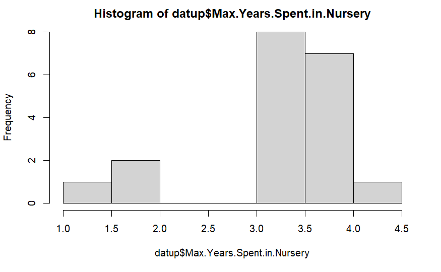

```r
hist(datup$Max.Years.Spent.in.Nursery)
```

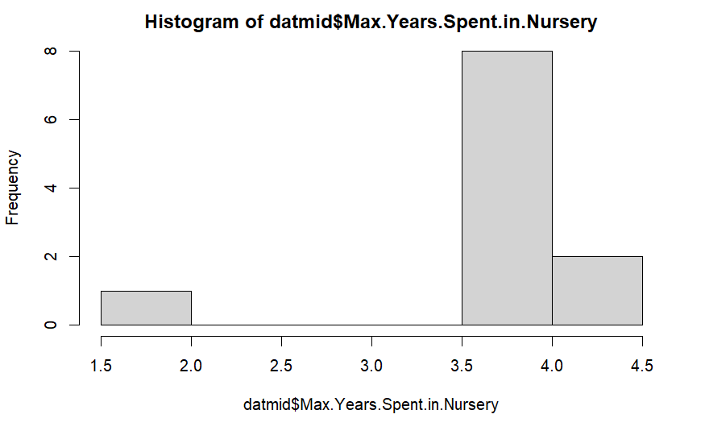

```r
hist(datmid$Max.Years.Spent.in.Nursery)
```

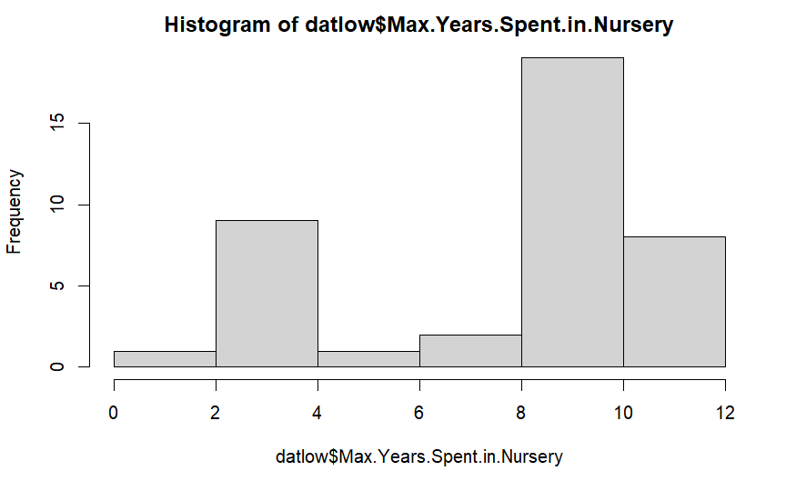

```r
hist(datlow$Max.Years.Spent.in.Nursery)
```

## Time normality test

```r
summary(fit1)
```

```
            Df Sum Sq Mean Sq F value   Pr(>F)
Region       2  392.6  196.30   32.52 1.35e-10 ***
Residuals   67  404.5    6.04
---
Signif. codes:  0 ‘***’ 0.001 ‘**’ 0.01 ‘*’ 0.05 ‘.’ 0.1 ‘ ’ 1
4 observations deleted due to missingness
```

## Time Kruskal Wallis test

```r
kruskal.test(Max.Years.Spent.in.Nursery~Region,data=dat)
```

```
    Kruskal-Wallis rank sum test

data:  Max.Years.Spent.in.Nursery by Region
Kruskal-Wallis chi-squared = 35.99, df = 2, p-value = 1.53e-08
```

## Time Pairwise Kruskal Wallis Test

### Max.Years.Spent.in.Nursery

| V1 | V2 | pvals | pvaladj |
| --- | --- | --- | --- |
| Middle Keys | Upper Keys | 0.277151296644201 | 8.314539e-01 |
| Lower Keys | Upper Keys | 5.18924074785366e-06 | 1.556772e-05 |
| Lower Keys | Middle Keys | 5.67780987859438e-06 | 1.703343e-05 |

## diversity versus time

### kruskal-wallis outlier by time

```r
kruskal.test(Max.Years.Spent.in.Nursery~Outlier,data = full_alpha)
```

```
    Kruskal-Wallis rank sum test

data:  Max.Years.Spent.in.Nursery by Outlier
Kruskal-Wallis chi-squared = 2.4999, df = 1, p-value = 0.1139
```

```r
summary(fit2)
```

```
Call:
lm(formula = log(shannon1) ~ Max.Years.Spent.in.Nursery, data = subset(noout_alpha,
    subset = Region == "Lower Keys"))

Residuals:
    Min      1Q  Median      3Q     Max
-0.8880 -0.3593 -0.1339  0.3913  0.9515

Coefficients:
                            Estimate Std. Error t value Pr(>|t|)
(Intercept)                -1.444287   0.242950  -5.945 1.02e-06 ***
Max.Years.Spent.in.Nursery -0.001193   0.027756  -0.043    0.966
---
Signif. codes:  0 ‘***’ 0.001 ‘**’ 0.01 ‘*’ 0.05 ‘.’ 0.1 ‘ ’ 1

Residual standard error: 0.4844 on 34 degrees of freedom
Multiple R-squared:  5.437e-05, Adjusted R-squared:  -0.02936
F-statistic: 0.001849 on 1 and 34 DF,  p-value: 0.966
```

```r
summary(fit2)
```

```
Call:
lm(formula = log(rich1) ~ Max.Years.Spent.in.Nursery, data = subset(noout_alpha,
    subset = Region == "Lower Keys"))

Residuals:
     Min       1Q   Median       3Q      Max
-0.62199 -0.20168 -0.04849  0.14036  0.90147

Coefficients:
                           Estimate Std. Error t value Pr(>|t|)
(Intercept)                 3.18463    0.16894  18.851  < 2e-16 ***
Max.Years.Spent.in.Nursery  0.07436    0.01930   3.853 0.000493 ***
---
Signif. codes:  0 ‘***’ 0.001 ‘**’ 0.01 ‘*’ 0.05 ‘.’ 0.1 ‘ ’ 1

Residual standard error: 0.3368 on 34 degrees of freedom
Multiple R-squared:  0.3039,    Adjusted R-squared:  0.2834
F-statistic: 14.84 on 1 and 34 DF,  p-value: 0.0004928
```

# ### now beta diversity

```r
fit2<- lm(1/sqrt(distances)~Max.Years.Spent.in.Nursery,data=subset(noout_alpha,subset=Region=="Lower Keys"))
shapiro.test(fit2$residuals)
```

```
    Shapiro-Wilk normality test

data:  fit2$residuals
W = 0.94126, p-value = 0.05559
```

```r
summary(fit2)
```

```
Call:
lm(formula = 1/sqrt(distances) ~ Max.Years.Spent.in.Nursery,
    data = subset(noout_alpha, subset = Region == "Lower Keys"))

Residuals:
    Min      1Q  Median      3Q     Max
-3.8571 -2.5077  0.5974  2.0293  5.0300

Coefficients:
                           Estimate Std. Error t value Pr(>|t|)
(Intercept)                  5.8612     1.2948   4.527 6.99e-05 ***
Max.Years.Spent.in.Nursery   0.1561     0.1479   1.056    0.299
---
Signif. codes:  0 ‘***’ 0.001 ‘**’ 0.01 ‘*’ 0.05 ‘.’ 0.1 ‘ ’ 1

Residual standard error: 2.581 on 34 degrees of freedom
Multiple R-squared:  0.03173,   Adjusted R-squared:  0.00325
F-statistic: 1.114 on 1 and 34 DF,  p-value: 0.2986
```

Because the time spent in the nursery is fairly “grouped” (see histograms), going to bin the data into short and long term in nursery for the lower keys genotypes

```r
lk.alpha<-subset(full_alpha,subset=Region=="Lower Keys")
lk.alpha$timebin<-ifelse(lk.alpha$Max.Years.Spent.in.Nursery<=5.86,"short","long")
t.test(subset(lk.alpha,lk.alpha$timebin=="long")$rich1,subset(lk.alpha,lk.alpha$timebin=="short")$rich1)
```

[output not shown]

### How many ASVs of? Aquarickettsia

## relative abundances

### make mycolors

```r
physeq.f<-phyloseq::filter_taxa(ps_acer, function(x) sum(x >= 100) > (0.01*length(x)), prune = TRUE) #filter out super small numbers
physeq.f
```

```
phyloseq-class experiment-level object
otu_table()   OTU Table:         [ 107 taxa and 74 samples ]
sample_data() Sample Data:       [ 74 samples by 16 sample variables ]
tax_table()   Taxonomy Table:    [ 107 taxa by 7 taxonomic ranks ]
```

```r
physeq.f.ra <- transform_sample_counts(physeq.f, function(x) x*100/sum(x))
physeq.f.ra.ord <- subset_taxa(physeq.f.ra,Genus=="Aquarickettsia")

propData <- as.data.frame((otu_table(physeq.f.ra.ord)))
plotDF <- propData %>%
  rownames_to_column(var="taxa") %>%
  melt() %>%
  magrittr::set_names(c("sample", "taxa", "relab"))
head(plotDF)#just checking it worked
```

|  | sample | taxa | relab |
| --- | --- | --- | --- |
| 1 | AC1.4 | ASV_1 | 98.5696304 |
| 2 | AC10.4 | ASV_1 | 99.0580371 |
| 3 | AC13.22 | ASV_1 | 95.4476016 |
| 4 | AC20 | ASV_1 | 94.6829955 |
| 5 | AC29 | ASV_1 | 97.9261623 |
| 6 | AC3.19 | ASV_1 | 0.5499863 |

```r
taxonomy.2 <- tax_table(physeq.f) %>%
  as.data.frame() %>%
  rownames_to_column(var="taxa")
head(taxonomy.2)#just checking it worked
```

|  | taxa | Kingdom | Phylum | Class | Order | Family | Genus | Species |
| --- | --- | --- | --- | --- | --- | --- | --- | --- |
| 1 | ASV_1 | Bacteria | Proteobacteria | Alphaproteobacteria | Rickettsiales | Midichloriaceae | Aquarickettsia | Aquarickettsia |
| 2 | ASV_2 | Bacteria | Spirochaetes | Spirochaetia | Spirochaetales | Spirochaetaceae | Spirochaeta_2 | Genus_Spirochaeta_2 |
| 3 | ASV_3 | Bacteria | Proteobacteria |  |  | Unclassified_ASV_3 | Unclassified_ASV_3 | Unclassified_ASV_3 |
| 4 | ASV_4 | Bacteria | Spirochaetes | Spirochaetia | Spirochaetales | Spirochaetaceae | Spirochaeta_2 | Genus_Spirochaeta_2 |
| 5 | ASV_5 | Bacteria | Proteobacteria | Alphaproteobacteria | Rickettsiales | Midichloriaceae | Aquarickettsia | Aquarickettsia |
| 6 | ASV_6 | Bacteria | Proteobacteria | Alphaproteobacteria |  | Unclassified_ASV_6 | Unclassified_ASV_6 | Unclassified_ASV_6 |

```r
head(plotDF)#just checking it worked
```

|  | sample | taxa | relab |
| --- | --- | --- | --- |
| 1 | AC1.4 | ASV_1 | 98.5696304 |
| 2 | AC10.4 | ASV_1 | 99.0580371 |
| 3 | AC13.22 | ASV_1 | 95.4476016 |
| 4 | AC20 | ASV_1 | 94.6829955 |
| 5 | AC29 | ASV_1 | 97.9261623 |
| 6 | AC3.19 | ASV_1 | 0.5499863 |

```r
plotDF <- left_join(plotDF, taxonomy.2, by="taxa") %>%
  select(taxa, sample, relab, taxa) #would need to update here too if you change it.
head(plotDF)#just checking it worked
```

|  | taxa | sample | relab |
| --- | --- | --- | --- |
| 1 | ASV_1 | AC1.4 | 98.5696304 |
| 2 | ASV_1 | AC10.4 | 99.0580371 |
| 3 | ASV_1 | AC13.22 | 95.4476016 |
| 4 | ASV_1 | AC20 | 94.6829955 |
| 5 | ASV_1 | AC29 | 97.9261623 |
| 6 | ASV_1 | AC3.19 | 0.5499863 |

```r
sampdata<-data.frame(sample_data(physeq.f.ra.ord)) #make dataframe of the sample data
metadata.2 <- sampdata %>%
  rownames_to_column(var="sample") #make a column of rownames (sample)
head(metadata.2)
```

|  | sample | Sample.ID | Orig_geno_ID | X2020_Mote_ID | Genotype | Outlier | sampling_date | Species | Lat | Long | Region | collection_date | Baums_MSAT_clonal_ID | Proposed_pheno | Date.Introduced.into.Nursery | Max.Years.Spent.in.Nursery | Max.Years.Spent.from.Original.Collection |
| --- | --- | --- | --- | --- | --- | --- | --- | --- | --- | --- | --- | --- | --- | --- | --- | --- | --- |
| 1 | AC1.4 | AC1.4 | 1 | M-L-1 | 1.4 | No | 11/12/19 | cervicornis | 24.56937 | -81.33028 | Lower Keys | 2/23/08 | C1153 (AF) | Susceptible | 2/23/2008 | 11.718 | 11.718 |
| 2 | AC10.4 | AC10.4 | 10 | M-L-10 | 10.4 | No | 11/12/19 | cervicornis | 24.61515 | -81.37917 | Lower Keys | 2/23/08 | C1083 (DG) | Susceptible | 2/23/2008 | 11.718 | 11.718 |
| 3 | AC13.22 | AC13.22 | 13 | M-L-13 | 13.22 | No | 11/12/19 | cervicornis | 24.59592 | -81.37162 | Lower Keys | 12/1/09 | C1365 | Susceptible | 2/23/2008 | 11.718 | 11.718 |
| 4 | AC20 | AC20 | 20 | M-L-20 | 20 | No | 12/13/19 | cervicornis | 24.62167 | -81.36313 | Lower Keys | 12/15/09 | C1191 | Susceptible | 2/23/2008 | 11.718 | 11.721 |
| 5 | AC29 | AC29 | 29 | M-L-29 | 29 | No | 12/13/19 | cervicornis | 24.52172 | -81.57675 | Lower Keys | 5/28/10 | C1377 | NA | 2/23/2008 | 11.803 | 11.806 |
| 6 | AC3.19 | AC3.19 | 3 | M-L-3 | 3.19 | Yes | 11/12/19 | cervicornis | 24.56307 | -81.40100 | Lower Keys | 2/23/08 | C1155 (BR) | Resistant | 2/23/2008 | 11.718 | 11.718 |

```r
#combine plotDF1 and metadata.2 by sample name
plotDF <- left_join(plotDF, metadata.2, by="sample")
head(plotDF) #just checking it worked
```

|  | taxa | sample | relab | Sample.ID | Orig_geno_ID | X2020_Mote_ID | Genotype | Outlier | sampling_date | Species | Lat | Long | Region | collection_date | Baums_MSAT_clonal_ID | Proposed_pheno | Date.Introduced.into.Nursery | Max.Years.Spent.in.Nursery | Max.Years.Spent.from.Original.Collection |
| --- | --- | --- | --- | --- | --- | --- | --- | --- | --- | --- | --- | --- | --- | --- | --- | --- | --- | --- | --- |
| 1 | ASV_1 | AC1.4 | 98.5696304 | AC1.4 | 1 | M-L-1 | 1.4 | No | 11/12/19 | cervicornis | 24.56937 | -81.33028 | Lower Keys | 2/23/08 | C1153 (AF) | Susceptible | 2/23/2008 | 11.718 | 11.718 |
| 2 | ASV_1 | AC10.4 | 99.0580371 | AC10.4 | 10 | M-L-10 | 10.4 | No | 11/12/19 | cervicornis | 24.61515 | -81.37917 | Lower Keys | 2/23/08 | C1083 (DG) | Susceptible | 2/23/2008 | 11.718 | 11.718 |
| 3 | ASV_1 | AC13.22 | 95.4476016 | AC13.22 | 13 | M-L-13 | 13.22 | No | 11/12/19 | cervicornis | 24.59592 | -81.37162 | Lower Keys | 12/1/09 | C1365 | Susceptible | 2/23/2008 | 11.718 | 11.718 |
| 4 | ASV_1 | AC20 | 94.6829955 | AC20 | 20 | M-L-20 | 20 | No | 12/13/19 | cervicornis | 24.62167 | -81.36313 | Lower Keys | 12/15/09 | C1191 | Susceptible | 2/23/2008 | 11.718 | 11.721 |
| 5 | ASV_1 | AC29 | 97.9261623 | AC29 | 29 | M-L-29 | 29 | No | 12/13/19 | cervicornis | 24.52172 | -81.57675 | Lower Keys | 5/28/10 | C1377 | NA | 2/23/2008 | 11.803 | 11.806 |
| 6 | ASV_1 | AC3.19 | 0.5499863 | AC3.19 | 3 | M-L-3 | 3.19 | Yes | 11/12/19 | cervicornis | 24.56307 | -81.40100 | Lower Keys | 2/23/08 | C1155 (BR) | Resistant | 2/23/2008 | 11.718 | 11.718 |

```r
NA
```

#### set colors

```r
length(levels(factor(plotDF$taxa)))
```

```
[1] 5
```

```r
mycolors <- c("#1B9E77","aquamarine3","cadetblue3","turquoise1","turquoise4")
names(mycolors)<-levels(factor(plotDF$taxa))
mycolors
```

```
        ASV_1        ASV_16        ASV_48         ASV_5        ASV_54
    "#1B9E77" "aquamarine3"  "cadetblue3"  "turquoise1"  "turquoise4"
```

```r
#mycolors<-c("#999999", "#FFFF00",  "#CC3300","#0072B2","#660066", "#E69F00", "#56B4E9","#CC79A7","#1B9E77","#AAE247") #colors used by Grace?
```

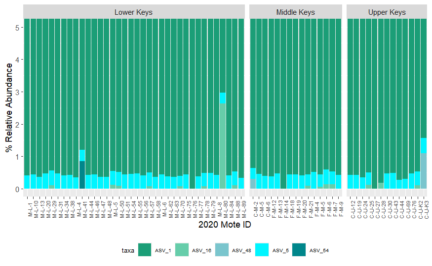

### ASV1

From Reviewer 2: It is strange that Aquarickettsia ASV1 was detected as differentially abundant in the Lower Keys compared to both the Middle and Upper Keys (Panels A & B) when the relative abundance of this ASV1 is very similar across regions (Panel C). If you plotted the relative abundance of ASV1 for each genotype in a box & whisker plot (like figs. 4, 5) would it show the pattern behind this?

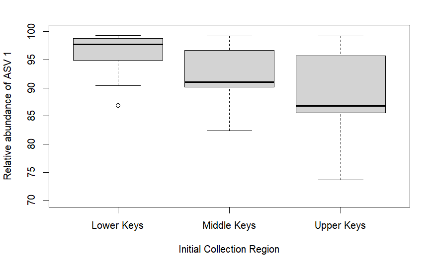

```r
asv1<-subset(plotDF2,taxa=="ASV_1")
boxplot(asv1$relab~asv1$Region,ylim=c(70,100),ylab="Relative abundance of ASV 1",xlab="Initial Collection Region")
```